# GSVA

SAR: NA , Study: NA

Siying Huang (E0482362), Biomarker statistics team

created: 2023-06-09 , updated (2023-11-29)

```r
library(here)
library(dplyr)
library(pheatmap)
source(file.path(here(), "src/utils.R"))
```

# Gene set variation analysis (GSVA)

The gene set variation analysis (GSVA) was developed by [*Hänzelmann et al*](https://www.ncbi.nlm.nih.gov/pmc/articles/PMC3618321/#sec-4title) in 2013, which is a non-parametric, unsupervised method for gene set enrichement analysis. Hänzelmann, Castelo, and Guinney (2013)[^1]

> GSVA calculates sample-wise gene set enrichment scores as a function of genes inside and outside the gene set, analogously to a competitive gene set test. Further, it estimates variation of gene set enrichment over the samples independently of any class label.

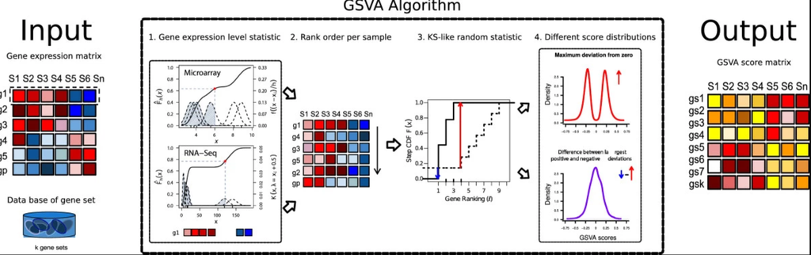

The major steps for GSVA method:

- rank and normalize gene expression levels across samples with CDF function.
- rank the gene expression levels within a sample
- calculate enrichment score (ES) and KS test
- calculate enrichment statistics (GSVA score)

## Smoking study

For simlipcity, I choose 5 smokers and 5 non-smokers out of the original dataset. And for the background gene set, I randomly choose 100 genes.

### Gene set selection

Here I select the genes of each set1 in the same manner as before. While for geneset 2 and 3, I choose up and down-regulated genes only for each set.

```r
set.seed(123)
gs1 <- sample(rst$ID, 10)
gs2 <- sample(rst[which(rst$logFC > 20 & rst$adj.P.Val < 0.0001), "ID"], 10)
gs3 <- sample(rst[which(rst$logFC < -20 & rst$adj.P.Val < 0.0001), "ID"], 10)

cat("set1:", gs1, "\nset2:", gs2, "\nset3:", gs3)
```

```
set1: HAUS5 MYDGF TRAPPC13 LINS1 SLC14A1 DYRK3 EIF3I NRP2 207479_at SESN1
set2: RASA2 LOC101060747 BCL11A CYBB ATP8A1 TCEB3 CIAO1 CERS4 SF3B1 EZR
set3: PTPRN 217679_x_at EVA1B AK021505 AK024602 KCNK10 214316_x_at CHRNA2 POLR2J4 AK022170
```

For the purpose of illustration and simplification, I randomly choose another 100 genes in the expression dataset as background gene.

## Gene set variation calculation

Here I use the geneset 1 (randomly selected genes) to illustration the GSVA process.

### Density function of gene expression levels

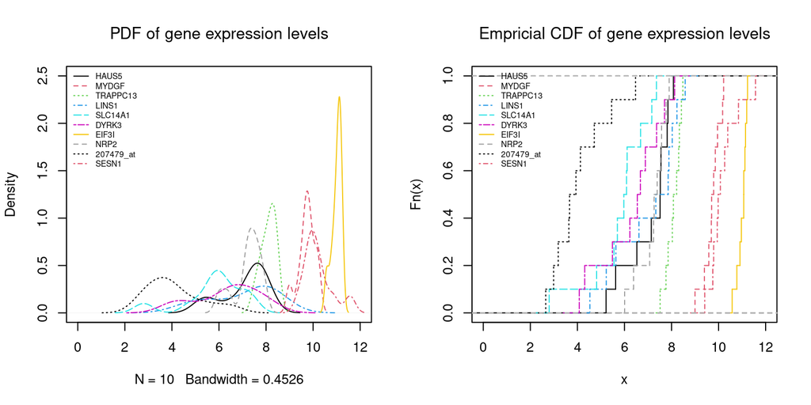

## Normalizing gene expression levels

In order to be able to compare the gene expression levels on the same scale for the genes in a gene set. One will need to normalize the expression levels.This is done using culmulative density function $F_x$.

```r
gd <- apply(expr_g, 1, function(x) {
  f <- ecdf(x)
  f(x)
}) %>%
  t() %>%
  data.frame() %>%
  setNames(colnames(expr_g))

gd <- apply(gd, 2, function(x) ifelse(x == 1, 0.99, x))
# normalize gene density
gene_density <- data.frame(log(gd / (1 - gd)))
```

Here I plot the **emprical CDF** instead of the explicit CDF mentioned in the paper for the purpose of illustration. For microarray data or continous data, the kernel for estimating CDF is Gaussian function, whereas in the count data, the kernel for CDF estimation is Poisson function 🐟.

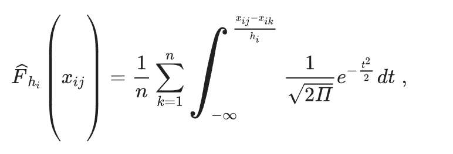

Gaussian kernel

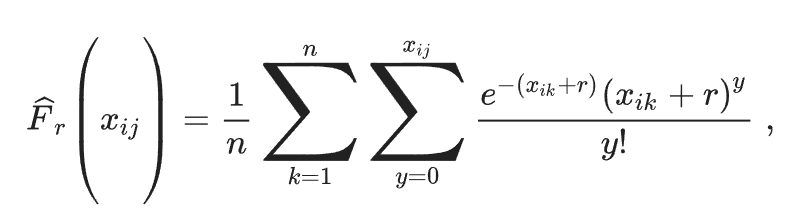

Poisson kernel

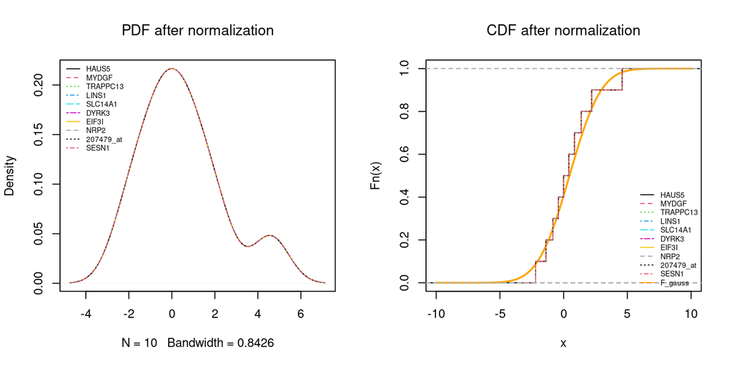

## Sample-wise enrichment scores

Next, within each **sample**, the gene expression levels are reordered. To normalize further, a rank score is computated within each sample.

### Compute rank score

> To reduce the influence of potential outliers, we first convert $z_{ij}$ to ranks $z(i)j$ for each sample j and normalize further $r_{ij}=|p/2−z_{(i)j}|$ to make the ranks symmetric around zero.

```r
sort_sgn_idxs <- apply(gene_density, 2, order, decreasing = TRUE)
rownames(sort_sgn_idxs) <- rownames(expr_g)

rank_norm <- apply(sort_sgn_idxs, 2, compute_rank_score)
rownames(rank_norm) <- rownames(sort_sgn_idxs)
```

### Enrichement score (ES)

The ES in GSVA is similar to GSVA using [two-sample Kolmogorov-Smirnov (KS)](https://en.wikipedia.org/wiki/Kolmogorov%E2%80%93Smirnov_test#Two-sample_Kolmogorov%E2%80%93Smirnov_test) like random walk statistic. Here I illustrate calculating ES in one sample. I set $\tau = 1$.

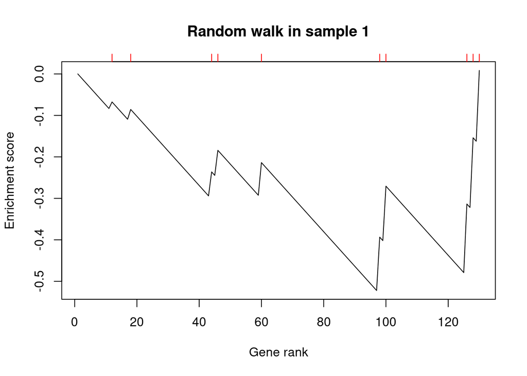

```r
n_tot = nrow(expr_g)
n_gs = length(gs1)

sample <- rank_norm[, 1, drop = F] %>%
  data.frame() %>%
  tibble::rownames_to_column("ID") %>%
  mutate(gs1 = ID %in% gs1) %>%
  rename(rscore = GSM464697) %>%
    arrange(rscore)
sum_gs = sum(sample[sample$gs1, "rscore"])
dnom = 1/ (n_tot - n_gs)

sample <- sample %>%
  mutate(
    score = if_else(gs1, abs(rscore) / sum_gs, -as.numeric(!gs1) * dnom)
  ) %>%
  mutate(
    score = case_when(row_number() == 1 ~ 0, TRUE ~ score),
    es = cumsum(score)
  )
plot(sample$es,
  type = "l",
  xlab = "Gene rank",
  ylab = "Enrichment score",
  main = "Random walk in sample 1"
)
axis(side = 3, at = which(sample$gs1), label = F, col.ticks = "red")
```

#### KS statistics

Here I simplify the test to a classic KS test. Notice the difference in weight at each step from the random walk plot above.

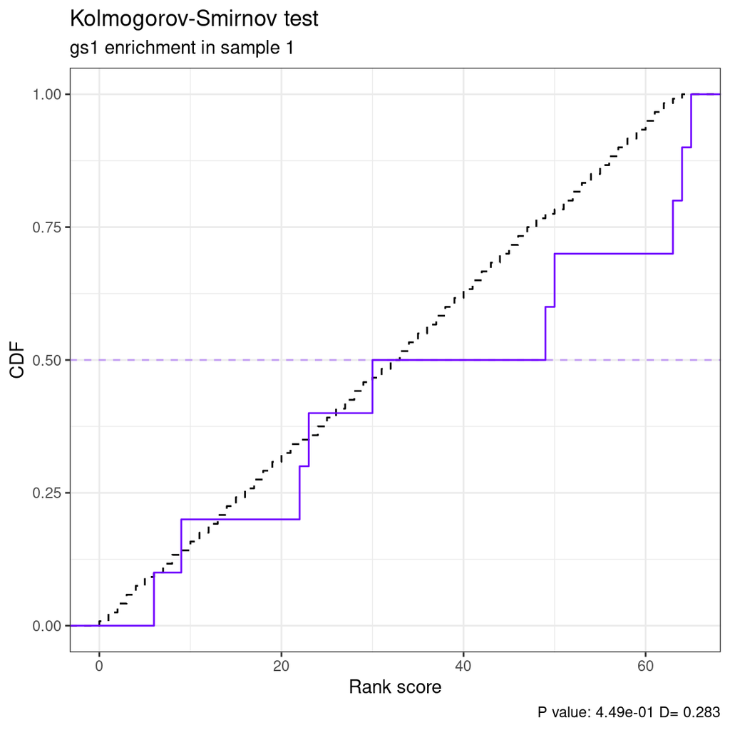

```r
ks_test_plot(sample, "ID", "rscore",
  gs1, "gs1 enrichment in sample 1",
  xlab = "Rank score",
  exact = F,
  mexclude = T
)
```

Similarly one can look at the other two pathways in sample 1.

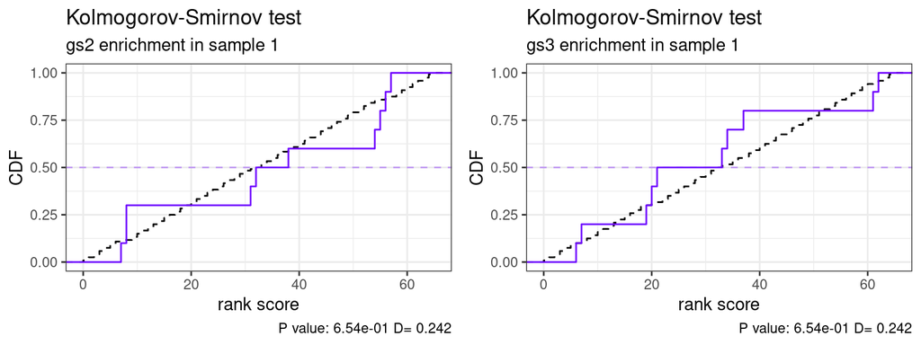

### Enrichemnent statistics

In GSVA, two approaches were proposed to turn KS random walk statistics into enrichment statistics, AKA, **GSVA score**.

> We offer two approaches for turning the KS like random walk statistic into an enrichment statistic (ES) (also called GSVA score), the classical maximum deviation method and a normalized ES. The first ES is the maximum deviation from zero of the random walk of the j-th sample with respect to the k-th gene set:

$$ES_{jk}^{max}= \nu_{jk}[arg max_{l = 1..p}(|\nu_{jk}{l}|)]$$

```r
max(abs(sample[, "es", drop = F]))
```

```
[1] 0.5221129
```

```r
# plot(sample$es, type = "l")
# abline(v = which.max(abs(sample$es)), col = "red", lty = 3)
```

#### Normalized enrichment score

$$ES_{jk}^{diff} = |ES_{jk}^+|+|ES_{jk}^-|$$

> where $|ES_{jk}^+|$ and $|ES_{jk}^-|$ are the largest positive and negative random walk deviations from zero, respectively, for sample j and gene set k.

```r
max(sample[, "es", drop = F], 0) - min(sample[, "es", drop = F], 0)
```

```
[1] 0.5304462
```

#### Distribution of GSVA score

Like the distribution in Eenrichment Score in GSEA, the null distribution of first option Eenrichment Statistics in GSVA is also bimodal.

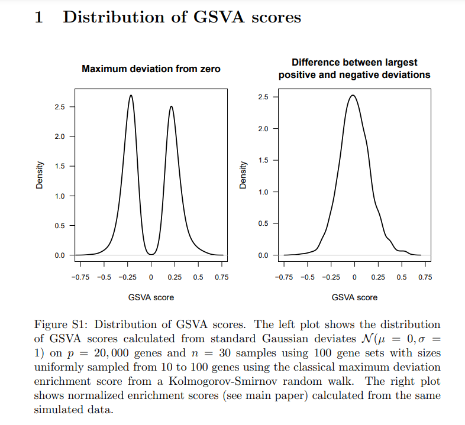

> – Supplemental material

## GSVA using R package

In this section, I demonstrate GSVA using `GSVA` library in R. The `gsva`function mainly takes expression data, gene set list and calculate enrichment statistics (GSVA score) with two options mentioned above. By default `gsva` and `gaussian` kernel are selected for the GSVA calculation. Other methods are implemented in this function as well (details in the next section).

```r
library(GSVA)
gene_sets <- list(gs1 = gs1, gs2 = gs2, gs3 = gs3)
expr_mtx <- as.matrix(expr_g)
es_gsva <- gsva(
  expr_mtx,
  gset.idx.list = gene_sets,
  mx.diff = F
)
```

```
Estimating GSVA scores for 3 gene sets.
Estimating ECDFs with Gaussian kernels
```

### Visualize pathway level enrichment in each sample

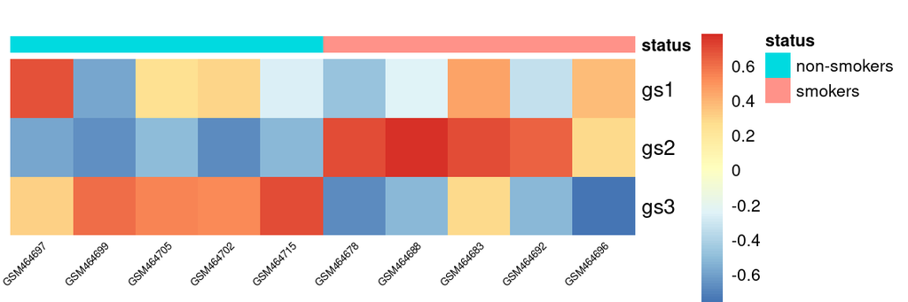

## Other GSVA-like methods

It is possible to use three other methods in the `GSVA` package. These are PLAGE, Z-scores and ssGSEA. I briefly describe these methods below.

### [PLAGE](https://www.ncbi.nlm.nih.gov/pmc/articles/PMC1261155/) Tomfohr, Lu, and Kepler (2005)

> standardizes each gene expression profile over the samples and then estimates the pathway activity profiles for each gene set as the coefficients of the first right-singular vector of the singular value decomposition of the gene set. It assume joint normal distributions in gene expression profiles.

### [Z-scores](https://journals.plos.org/ploscompbiol/article?id=10.1371/journal.pcbi.1000217) Lee et al. (2008)

> The combined z-score method standardizes first, as PLAGE, each gene expression profile into z-scores but the pathway activity profile is then obtained by combining the individual gene z-scores per sample. It assumes the gene expression profile are jointly normally distributioned. The combined z-score additionally assumes that genes act **independently** within each gene set.

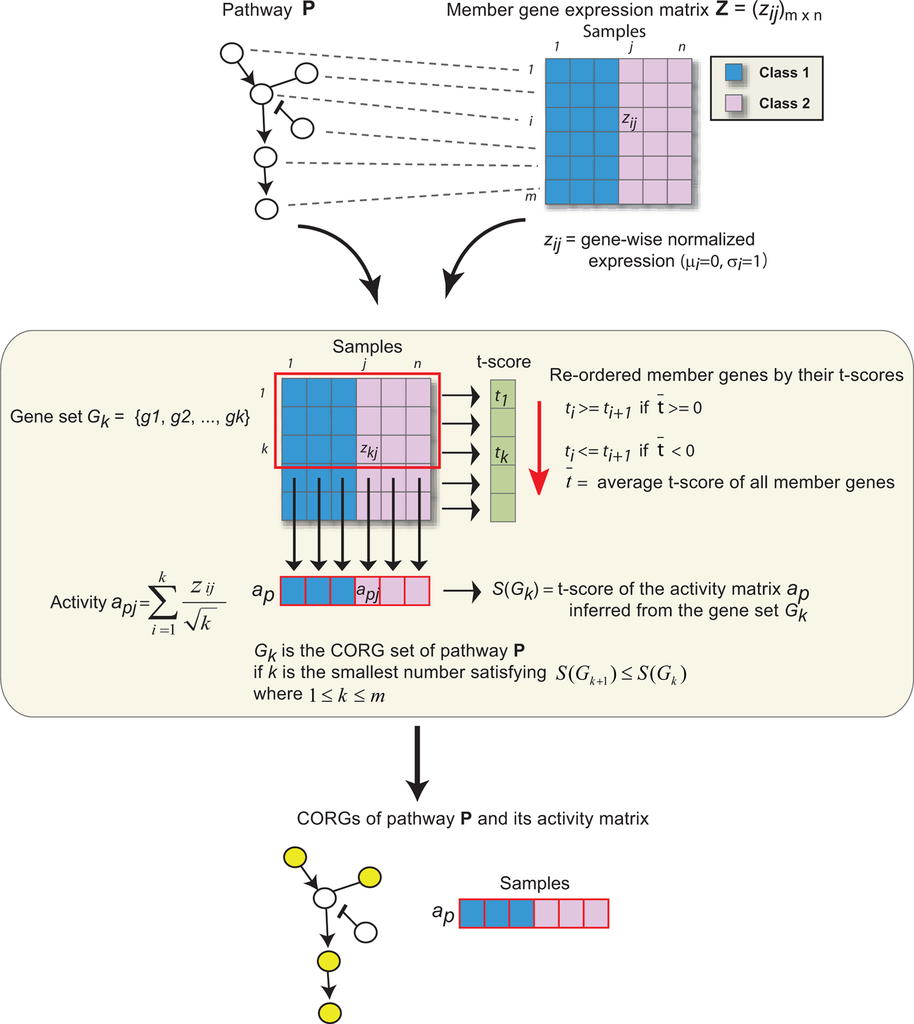

### [ssGSEA](https://www.nature.com/articles/nature08460) Barbie et al. (2009)

> It uses the difference in *empirical cumulative distribution functions* of gene expression ranks inside and outside the gene set to calculate an enrichment statistic per sample which is further normalized by the range of values taken throughout all gene sets and samples. (The demonstration above uses eCDF.)

## Implication of GSVA score

The most frequencly used output from GSVA is the GSVA score, which is usually in a format of matrix. This matrix can be used for downstream analyses, such as hypothesis testing, classification, etc. There are some questions raise from using GSVA score in the downstream analysis. One of the example is the R [`xCell`](https://genomebiology.biomedcentral.com/articles/10.1186/s13059-017-1349-1) package, which calculate cell type enrichment score using ssGSEA method from `GSVA` package.

## Reference

Barbie, David A., Pablo Tamayo, Jesse S. Boehm, So Young Kim, Susan E. Moody, Ian F. Dunn, Anna C. Schinzel, et al. 2009. “Systematic RNA Interference Reveals That Oncogenic KRAS-Driven Cancers Require Tbk1.” *Nature* 462 (7269): 108–12. https://doi.org/10.1038/nature08460.

Hänzelmann, Sonja, Robert Castelo, and Justin Guinney. 2013. “GSVA: Gene Set Variation Analysis for Microarray and RNA-Seq Data.” *BMC Bioinformatics* 14 (1): 7. https://doi.org/10.1186/1471-2105-14-7.

Lee, Eunjung, Han-Yu Chuang, Jong-Won Kim, Trey Ideker, and Doheon Lee. 2008. “Inferring Pathway Activity Toward Precise Disease Classification.” *PLOS Computational Biology* 4 (11): e1000217. https://doi.org/10.1371/journal.pcbi.1000217.

Tomfohr, John, Jun Lu, and Thomas B. Kepler. 2005. “Pathway Level Analysis of Gene Expression Using Singular Value Decomposition.” *BMC Bioinformatics* 6 (1): 225. https://doi.org/10.1186/1471-2105-6-225.

[^1]: All quoted text are from original paper.